# Touch of Modern Assignment

Load the packages used in the assignment.

```r
require(RSQLite)
require(XLConnect)
library(dplyr)
library(ggplot2)
```

Load the Data into a sqlite database from csv provided.

```r
location_csv <- "/Users/neilbhatt/Documents/Touch of Modern/"
db <- dbConnect(SQLite(), dbname="TouchOfModern.sqlite")
dbWriteTable(conn=db, name = "orders", value=paste0(location_csv,"orders.csv"))
```

```
[1] TRUE
```

```r
dbWriteTable(conn=db, name = "users", value=paste0(location_csv,"users.csv"))
```

```
[1] TRUE
```

```r
users <- dbGetQuery(db, "SELECT * FROM users")
orders <- dbGetQuery(db, "SELECT * FROM orders")
```

Top 10 Spenders

```r
T10_spenders <- dbGetQuery(db, "SELECT user_id, SUM(item_total - discounts_applied)
                           FROM orders
                           WHERE payment_reject = 'False'
                           GROUP BY 1
                           ORDER BY 2 desc
                           LIMIT 10")
T10_spenders
```

| user_id | SUM(item_total - discounts_applied) |
| --- | --- |
| 7420 | 6307.38 |
| 2638 | 6301.95 |
| 6431 | 6242.29 |
| 7984 | 5666.70 |
| 7206 | 5539.64 |
| 9232 | 5219.75 |
| 4547 | 5098.86 |
| 2985 | 5065.90 |
| 2601 | 5052.97 |
| 7958 | 4861.87 |

Second Highest Orders by User

```r
SecondHighestOrders <- dbGetQuery(db, "SELECT a.user_id, MAX(a.item_total)
                                  FROM orders a
                                  JOIN (SELECT user_id, MAX(item_total) as MX FROM orders WHERE                                                 payment_reject = 'False'
                                        GROUP BY 1) b ON b.user_id = a.user_id
                                  WHERE payment_reject = 'False'
                                  AND item_total < b.MX
                                  GROUP BY 1")
SecondHighestOrders
```

| user_id | MAX(a.item_total) |
| --- | --- |
| 2 | 176.22 |
| 3 | 115.42 |
| 4 | 143.94 |
| 5 | 165.57 |
| 7 | 137.25 |
| 9 | 179.54 |
| 10 | 152.40 |
| 11 | 178.92 |
| 13 | 153.64 |
| 14 | 71.06 |

[output cut: 990 more lines]

Validate above results.

```r
##Highest Orders used to validate results from above (second highest < highest)
HighestOrders <- dbGetQuery(db,"SELECT a.user_id, MAX(a.item_total)
                            FROM orders a GROUP BY 1")
db2 <- dbGetQuery(db, "SELECT b.user_id FROM (SELECT a.user_id, count(a.id) as CT FROM orders a WHERE a.payment_reject = 'False' group by 1) b
                  WHERE b.CT > 1")
```

Number of shipping levels

```r
dbGetQuery(db, "SELECT Distinct shipping_cost from orders")
```

| shipping_cost |
| --- |
| 10 |
| 15 |
| 25 |
| 20 |

There are only 4 distinct shipping costs.

Statistics based on Shipping Levels

```r
Shipping_Table <- orders %>% group_by(shipping_cost) %>% summarize(mean = mean(item_total),
                                                                   min = min(item_total),
                                                                   med=median(item_total),
                                                                   max=max(item_total))
Shipping_Table <- cbind(Shipping_Table, orders %>% group_by(shipping_cost) %>% tally)
Shipping_Table
```

| shipping_cost | mean | min | med | max | shipping_cost | n |
| --- | --- | --- | --- | --- | --- | --- |
| 10 | 90.22360 | 43.04 | 93.21 | 114.99 | 10 | 18739 |
| 15 | 147.87388 | 115.00 | 144.76 | 207.94 | 15 | 28250 |
| 20 | 96.01307 | 58.22 | 98.24 | 114.99 | 20 | 1162 |
| 25 | 156.09579 | 115.02 | 153.75 | 222.96 | 25 | 3587 |

```r
cor(Shipping_Table$shipping_cost, Shipping_Table$n)
```

```
[1] -0.7296666
```

The negative correlation is not in line with economic expectations which adds that the shipping cost may not be influencing user purchase behavior. Though cart abandonment data would provide a much clearer picture.

To identify trends, I look into day of orders.

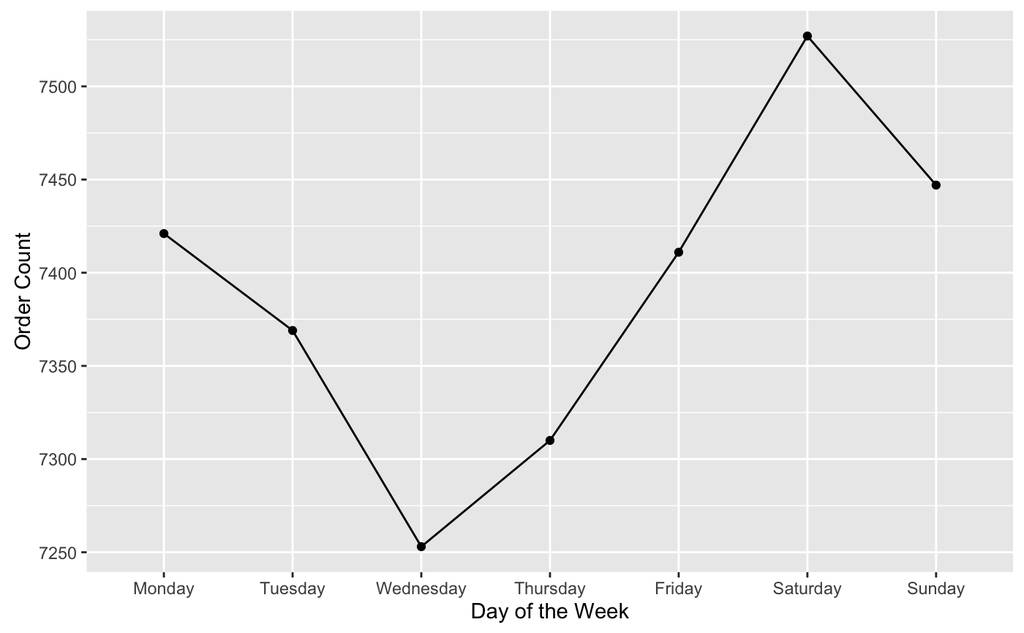

```r
orders$day <- weekdays(as.Date(orders$order_time))
By_day <- orders %>% group_by(day) %>% summarize(mean = mean(item_total), min = min(item_total), med=median(item_total), max=max(item_total))
By_day <- cbind(By_day, orders %>% group_by(day) %>% tally)
Day_plot <- ggplot(data=By_day, aes(x=day, y=n,group=1)) +
  geom_point(stat="identity", fill="steelblue") + geom_line() +
  scale_x_discrete(limits=c('Monday','Tuesday','Wednesday','Thursday','Friday','Saturday','Sunday'))+
  xlab('Day of the Week') + ylab('Order Count')
Day_plot
```

Saturday, Sunday, Monday are the highest order days; Wednesday has the lowest orders Ramp up Wednesday thru Saturday, Decline Saturday thru Wednesday

Next, I looked at order count.

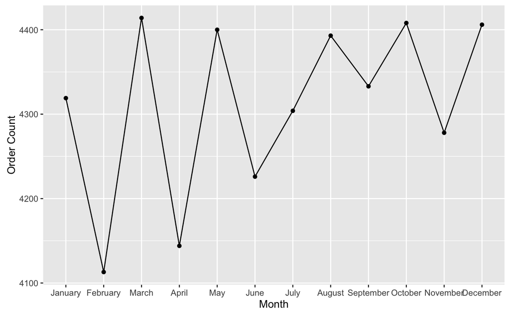

```r
orders$month <- format(as.Date(orders$order_time),format="%B")
By_month <- orders %>% group_by(month) %>% summarize(mean = mean(item_total), min = min(item_total), med=median(item_total), max=max(item_total))
By_month <- cbind(By_month, orders %>% group_by(month) %>% tally)
Month_plot <- ggplot(data=By_month, aes(x=month, y=n, group=1)) +
  geom_point(stat="identity", fill="steelblue") + geom_line() +
  scale_x_discrete(limits=c('January','February','March','April','May','June','July','August','September','October','November','December'))+
  xlab('Month') + ylab('Order Count')
Month_plot
```

I break out revenue by country.

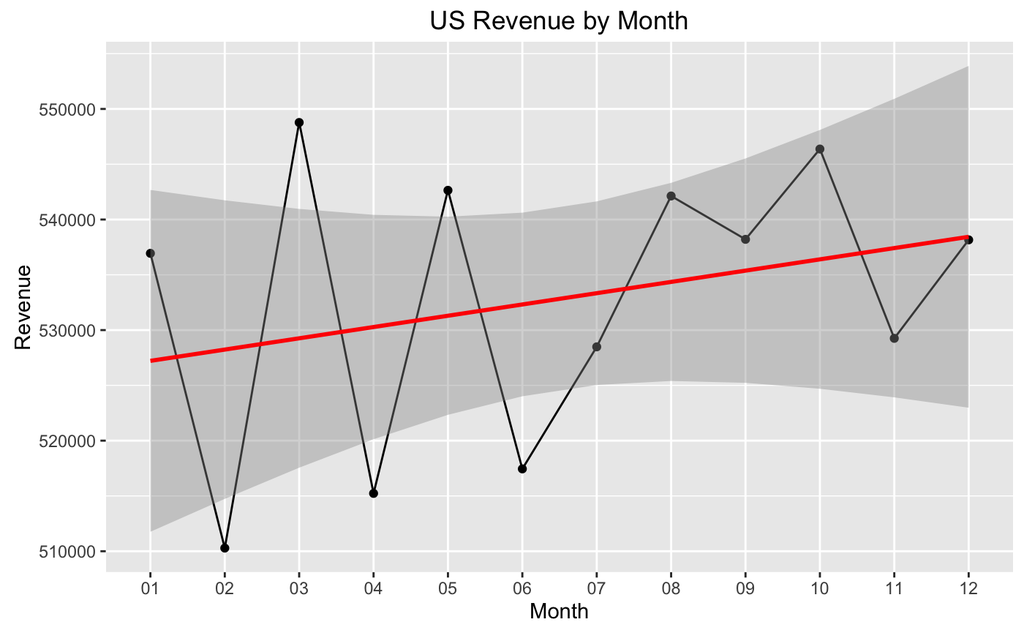

```r
REV_US <- dbGetQuery(db, "SELECT strftime('%m', a.order_time) AS Date, SUM(a.item_total + a.shipping_cost - a.discounts_applied) AS REV
                  FROM orders a
                  JOIN users b ON a.user_id = b.id
                  WHERE payment_reject = 'False'
                  AND b.country = 'US'
                  GROUP BY 1
                  ORDER BY 1 asc")
MonthREV_plot_US <- ggplot(data=REV_US, aes(x=Date, y=REV, group=1)) +
  geom_point(stat="identity", fill="steelblue") + geom_line() +
  xlab('Month') + ylab('Revenue') +ggtitle("US Revenue by Month") + geom_smooth(method = "lm",colour='red')
MonthREV_plot_US
```

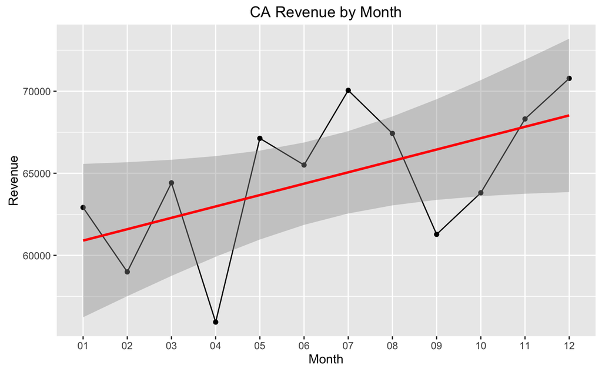

```r
REV_CA <- dbGetQuery(db, "SELECT strftime('%m', a.order_time) AS Date, SUM(a.item_total + a.shipping_cost - a.discounts_applied) AS REV
                     FROM orders a
                     JOIN users b ON a.user_id = b.id
                     WHERE payment_reject = 'False'
                     AND b.country = 'CA'
                     GROUP BY 1
                     ORDER BY 1 asc")
MonthREV_plot_CA <- ggplot(data=REV_CA, aes(x=Date, y=REV, group=1)) +
  geom_point(stat="identity", fill="steelblue") + geom_line() +
  xlab('Month') + ylab('Revenue') +ggtitle("CA Revenue by Month") + geom_smooth(method = "lm",colour='red')
MonthREV_plot_CA
```

There is definitely some seasonality with March, May, August, October, December peaks and troughs in February, April, June, September, November. CA has a larger MoM revenue growth rate than the US does bassed on the linear regression model.

I then look into how frequently users are purchasing in a given year.

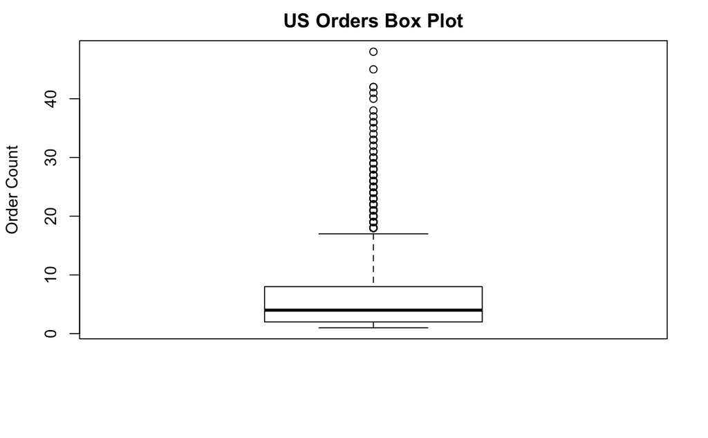

```r
order_count_US <- dbGetQuery(db, "SELECT a.user_id, count(a.id) as order_count, sum(item_total) as                               item_rev
                          FROM orders a
                          JOIN users b ON a.user_id = b.id
                          WHERE payment_reject = 'False'
                          AND b.country = 'US'
                          GROUP BY 1")
US_Boxplot <- boxplot(as.numeric(order_count_US$order_count), main="US Orders Box Plot", ylab="Order Count")
```

```r
summary(order_count_US$order_count)
```

```
   Min. 1st Qu.  Median    Mean 3rd Qu.    Max.
  1.000   2.000   4.000   5.611   8.000  48.000
```

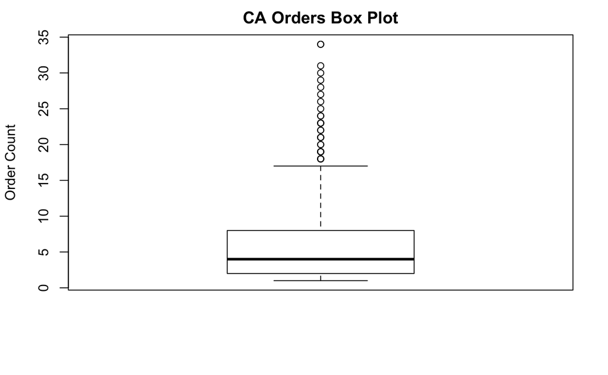

```r
order_count_CA <- dbGetQuery(db, "SELECT a.user_id, count(a.id) as order_count, sum(item_total) as item_rev
                             FROM orders a
                             JOIN users b ON a.user_id = b.id
                             WHERE payment_reject = 'False'
                             AND b.country = 'CA'
                             GROUP BY 1")
CA_Boxplot <- boxplot(order_count_CA$order_count, main="CA Orders Box Plot", ylab="Order Count")
```

```r
summary(order_count_CA$order_count)
```

```
   Min. 1st Qu.  Median    Mean 3rd Qu.    Max.
  1.000   2.000   4.000   5.804   8.000  34.000
```

A typical customer made 4 purchases in the year, 25% of the users made more than 8 purchases in a year. US users have a higher max number of orders per year by user than CA.

I then broke down and pivoted by gender and country.

```r
order_count_gender <- dbGetQuery(db, "SELECT a.user_id,b.gender,b.country,
                             count(a.id) as order_count,
                             sum(item_total+shipping_cost-discounts_applied) as REV
                             FROM orders a
                             JOIN users b ON a.user_id = b.id
                             WHERE payment_reject = 'False'
                             GROUP BY 1")
country_gender<-order_count_gender %>% group_by(gender,country) %>%
  summarize(mean = mean(REV), min = min(REV), med=median(REV), max=max(REV))
country_gender<-cbind(country_gender, order_count_gender %>% group_by(gender, country) %>% tally)
country_gender
```

| gender | country | mean | min | med | max | gender | country | n |
| --- | --- | --- | --- | --- | --- | --- | --- | --- |
|  | CA | 900.7575 | 86.03 | 569.745 | 4312.11 |  | CA | 282 |
|  | US | 785.8721 | 53.25 | 566.150 | 6927.38 |  | US | 2753 |
| F | CA | 957.4653 | 109.31 | 657.800 | 5825.90 | F | CA | 278 |
| F | US | 749.1587 | 54.56 | 542.870 | 6936.95 | F | US | 2807 |
| M | CA | 1017.3523 | 82.59 | 694.060 | 6044.75 | M | CA | 252 |
| M | US | 779.3152 | 54.53 | 563.065 | 6201.70 | M | US | 2730 |

```r
gender<-order_count_gender %>% group_by(gender) %>%
  summarize(mean = mean(REV), min = min(REV), med=median(REV), max=max(REV))
gender<-cbind(gender, order_count_gender %>% group_by(gender) %>% tally)
gender
```

| gender | mean | min | med | max | gender | n |
| --- | --- | --- | --- | --- | --- | --- |
|  | 796.5468 | 53.25 | 566.150 | 6927.38 |  | 3035 |
| F | 767.9300 | 54.56 | 548.860 | 6936.95 | F | 3085 |
| M | 799.4310 | 54.53 | 573.005 | 6201.70 | M | 2982 |

I then pivoted the data by gender, age range, and country. I split the tables so I could see the conclusions a bit easier.

```r
Age <- dbGetQuery(db, "SELECT a.user_id, b.gender,
                              Case when b.age <=19 THEN '0-20'
                                   when b.age >19 and b.age<=29 THEN '20-29'
                                   when b.age >29 and b.age<=39 THEN '30-39'
                                   when b.age >39 and b.age<=49 THEN '40-49'
                                   when b.age >49 and b.age<=59 THEN '50-59'
                                   when b.age >59 THEN '60+'
                                ELSE '' end as Age_Range, b.country,
                             count(a.id) as order_count,
                             sum(item_total+shipping_cost-discounts_applied) as REV
                    FROM orders a
                    JOIN users b ON a.user_id = b.id
                    WHERE payment_reject = 'False'
                    GROUP BY 1")
Age_Table_Gender <- Age %>% group_by(gender, Age_Range) %>%
  summarize(mean = mean(REV), min = min(REV), med=median(REV), max=max(REV))
Age_Table_Gender <-cbind(Age_Table_Gender, Age %>% group_by(gender, Age_Range) %>% tally)
Age_Table_Gender
```

| gender | Age_Range | mean | min | med | max | gender | Age_Range | n |
| --- | --- | --- | --- | --- | --- | --- | --- | --- |
|  | 20-29 | 664.0770 | 53.25 | 464.280 | 5076.63 |  | 20-29 | 805 |
|  | 30-39 | 758.5328 | 75.08 | 536.050 | 4677.45 |  | 30-39 | 895 |
|  | 40-49 | 913.1451 | 97.69 | 669.645 | 6927.38 |  | 40-49 | 876 |
|  | 50-59 | 880.4698 | 119.72 | 652.340 | 5014.00 |  | 50-59 | 459 |
| F | 20-29 | 635.1622 | 54.56 | 449.980 | 5187.80 | F | 20-29 | 849 |
| F | 30-39 | 728.4448 | 73.37 | 524.570 | 4702.46 | F | 30-39 | 864 |
| F | 40-49 | 845.3865 | 92.51 | 633.680 | 6936.95 | F | 40-49 | 910 |
| F | 50-59 | 933.1887 | 112.48 | 633.805 | 6054.64 | F | 50-59 | 462 |
| M | 20-29 | 671.9853 | 54.53 | 472.685 | 4600.53 | M | 20-29 | 746 |
| M | 30-39 | 757.8209 | 75.94 | 566.310 | 4764.40 | M | 30-39 | 915 |

[output cut: 2 more lines]

```r
Age_Table <- Age %>% group_by(Age_Range) %>%
  summarize(mean = mean(REV), min = min(REV), med=median(REV), max=max(REV))
Age_Table <-cbind(Age_Table, Age %>% group_by(Age_Range) %>% tally)
Age_Table
```

| Age_Range | mean | min | med | max | Age_Range | n |
| --- | --- | --- | --- | --- | --- | --- |
| 20-29 | 656.3065 | 53.25 | 462.465 | 5187.80 | 20-29 | 2400 |
| 30-39 | 748.5674 | 73.37 | 542.135 | 4764.40 | 30-39 | 2674 |
| 40-49 | 878.3170 | 92.51 | 639.990 | 6936.95 | 40-49 | 2694 |
| 50-59 | 920.1616 | 112.23 | 667.510 | 6201.70 | 50-59 | 1334 |

[output not shown]

The typical and average customer across genders tends to spend more the older they are, with most orders coming from male customers in their 30s then age group 40s, and coming from female customers in their 40s then age group 30s. By country grouping shows the same trend.

I then wanted to look at the relationship between purchases (revenue and order count) and days on site.

```r
onsite <- dbGetQuery(db, "SELECT a.user_id, b.gender, b.days_on_site_in_2016,
                          Case when b.age <=19 THEN '0-20'
                          when b.age >19 and b.age<=29 THEN '20-29'
                          when b.age >29 and b.age<=39 THEN '30-39'
                          when b.age >39 and b.age<=49 THEN '40-49'
                          when b.age >49 and b.age<=59 THEN '50-59'
                          when b.age >59 THEN '60+'
                          ELSE '' end as Age_Range,
                          count(a.id) as order_count,
                          sum(item_total+shipping_cost-discounts_applied) as REV
                      FROM orders a
                      JOIN users b ON a.user_id = b.id
                      WHERE payment_reject = 'False'
                      GROUP BY 1")
cor(onsite$days_on_site_in_2016,onsite$order_count)
```

```
[1] 0.9460318
```

```r
cor(onsite$days_on_site_in_2016,onsite$REV)
```

```
[1] 0.9172812
```

I wanted to see if there was any variation between days on site when broken down by gender.

```r
onsite_table <- onsite %>% group_by(gender) %>%
  summarize(mean = mean(days_on_site_in_2016), min = min(days_on_site_in_2016),
            med=median(days_on_site_in_2016), max=max(days_on_site_in_2016))
onsite_table <-cbind(onsite_table, onsite %>% group_by(gender) %>% tally)
onsite_table
```

| gender | mean | min | med | max | gender | n |
| --- | --- | --- | --- | --- | --- | --- |
|  | 11.30379 | 1 | 8 | 85 |  | 3035 |
| F | 11.08882 | 1 | 8 | 87 | F | 3085 |
| M | 11.26056 | 1 | 8 | 74 | M | 2982 |

On average males have spent more days on the site than females. The typical male or female spent 8 days on the site in 2016.

I also wanted to break down days on site by Age Range.

```r
onsite_table_age <- onsite %>% group_by(gender, Age_Range) %>%
  summarize(mean = mean(days_on_site_in_2016), min = min(days_on_site_in_2016),
            med=median(days_on_site_in_2016), max=max(days_on_site_in_2016))
onsite_table_age <-cbind(onsite_table_age, onsite %>% group_by(gender, Age_Range) %>% tally)
onsite_table_age
```

| gender | Age_Range | mean | min | med | max | gender | Age_Range | n |
| --- | --- | --- | --- | --- | --- | --- | --- | --- |
|  | 20-29 | 11.41739 | 1 | 8 | 70 |  | 20-29 | 805 |
|  | 30-39 | 11.42793 | 1 | 8 | 64 |  | 30-39 | 895 |
|  | 40-49 | 11.55023 | 1 | 8 | 85 |  | 40-49 | 876 |
|  | 50-59 | 10.39216 | 1 | 8 | 59 |  | 50-59 | 459 |
| F | 20-29 | 11.41225 | 1 | 8 | 79 | F | 20-29 | 849 |
| F | 30-39 | 10.91667 | 1 | 8 | 79 | F | 30-39 | 864 |
| F | 40-49 | 11.01758 | 1 | 8 | 87 | F | 40-49 | 910 |
| F | 50-59 | 10.95671 | 1 | 8 | 68 | F | 50-59 | 462 |
| M | 20-29 | 11.39008 | 1 | 8 | 65 | M | 20-29 | 746 |
| M | 30-39 | 11.20328 | 1 | 9 | 58 | M | 30-39 | 915 |

[output cut: 2 more lines]

When looking at days on site by Age typical male customer in their 30s and 50s spend an extra day on the site (9 days) versus all other groups (8 days).